# Lab 7: Functions + Fish

Author

Kallan Torell

The goal of this lab is learn more about exploring missing data and writing modular code.

```r
library(tidyverse)
fish <- read.csv("BlackfootFish.csv")
glimpse(fish)
```

```
Rows: 18,352
Columns: 7
$ trip    <int> 1, 1, 1, 1, 1, 1, 1, 1, 1, 1, 1, 1, 1, 1, 1, 1, 1, 1, 1, 1, 1,…
$ mark    <int> 0, 0, 0, 0, 0, 0, 0, 0, 0, 0, 0, 0, 0, 0, 0, 0, 0, 0, 0, 0, 0,…
$ length  <dbl> 288, 288, 285, 322, 312, 363, 269, 160, 213, 157, 143, 179, 19…
$ weight  <dbl> 175, 190, 245, 275, 300, 380, 170, 40, 80, 35, 35, 70, 100, 95…
$ year    <int> 1989, 1989, 1989, 1989, 1989, 1989, 1989, 1989, 1989, 1989, 19…
$ section <chr> "Johnsrud", "Johnsrud", "Johnsrud", "Johnsrud", "Johnsrud", "J…
$ species <chr> "RBT", "RBT", "RBT", "RBT", "RBT", "RBT", "RBT", "RBT", "RBT",…
```

## The Data

This lab’s data concerns mark-recapture data on four species of trout from the Blackfoot River outside of Helena, Montana. These four species are **rainbow trout (RBT)**, **westslope cutthroat trout (WCT)**, **bull trout**, and **brown trout**.

Mark-recapture is a common method used by ecologists to estimate a population’s size when it is impossible to conduct a census (count every animal). This method works by *tagging* animals with a tracking device so that scientists can track their movement and presence.

## Data Exploration

The measurements of each captured fish were taken by a biologist on a raft in the river. The lack of a laboratory setting opens the door to the possibility of measurement errors.

**1. Let’s look for missing values in the dataset. Output ONE table that answers BOTH of the following questions:**

- **How many observations have missing values?**
- **What variable(s) have missing values present?**

**You should use `across()`!**

```r
fish |>
  summarize(
    across(
      .cols  = everything(),
      .fns   = ~ sum(is.na(.)),
      .names = "missing_{col}"
    )
  ) |>
  pivot_longer(
    cols      = everything(),
    names_to  = "variable",
    values_to = "n_missing"
  ) |>
  mutate(
    variable = str_remove(variable, "^missing_")
  ) |>
  filter(n_missing > 0)
```

```
# A tibble: 1 × 2
  variable n_missing
  <chr>        <int>
1 weight        1796
```

```r
# https://www.rdocumentation.org/packages/tidyselect/versions/1.2.1/topics/everything
# been using everything() and i dont recall using it in class since I missed last week but it selects all remaining variables after other operations have been applied, like in this case pivot_longer() or other cases could be select() or across()
```

**2. Use a pivot to transform your summary table from Question 1 into a table that is easier to read.**

```r
fish |>
  summarize(
    across(
      .cols  = everything(),
      .fns   = ~ sum(is.na(.)),
      .names = "missing_{col}"
    )
  ) |>
  pivot_longer(
    cols      = everything(),
    names_to  = "variable",
    values_to = "count"
  ) |>
  mutate(variable = str_remove(variable, "^missing_")) |>
  pivot_wider(
    names_from   = variable,
    values_from  = count,
    values_fill  = 0,
    names_prefix = "missing_"
  )
```

```
# A tibble: 1 × 7
  missing_trip missing_mark missing_length missing_weight missing_year
         <int>        <int>          <int>          <int>        <int>
1            0            0              0           1796            0
# ℹ 2 more variables: missing_section <int>, missing_species <int>
```

**3. Create ONE thoughtful visualization that explores the frequency of missing values across the different years, sections, and trips.**

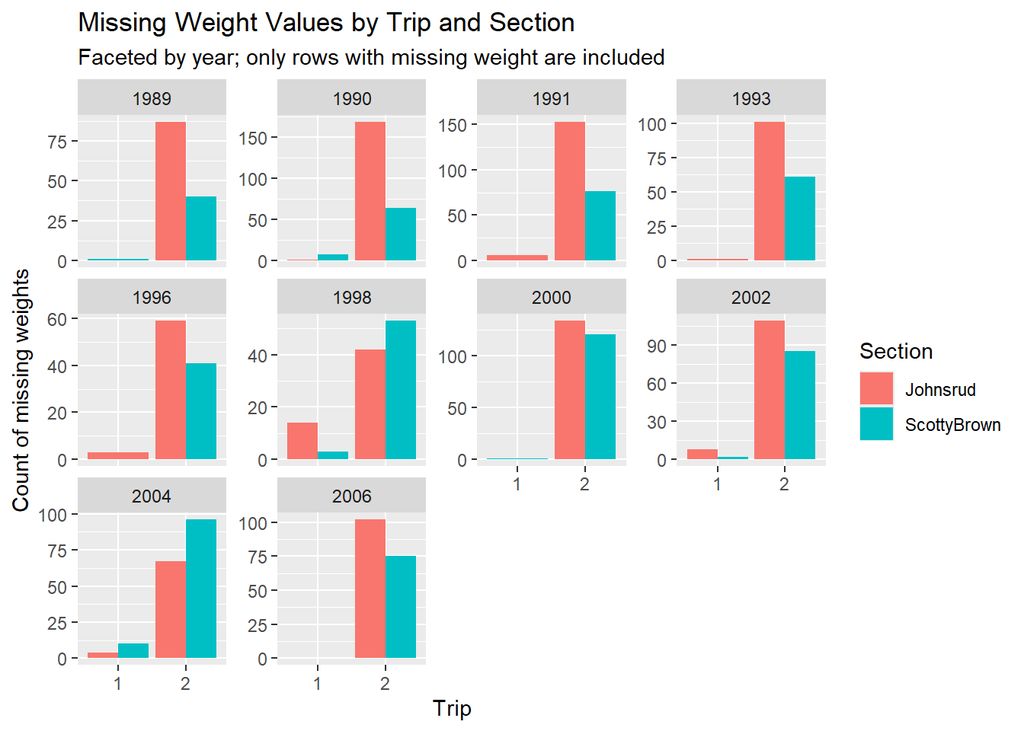

```r
library(ggplot2)

missing_weight_by_year_section_trip <-
  fish |>
  filter(is.na(weight)) |>
  count(year, section, trip, name = "n_missing")


ggplot(
  missing_weight_by_year_section_trip,
  aes(x = factor(trip), y = n_missing, fill = section)
) +
  geom_col(position = "dodge") +
  facet_wrap(~ year, scales = "free_y") +
  labs(
    title    = "Missing Weight Values by Trip and Section",
    subtitle = "Faceted by year; only rows with missing weight are included",
    x        = "Trip",
    y        = "Count of missing weights",
    fill     = "Section"
  )
```

```r
#https://ggplot2.tidyverse.org/reference/position_dodge.html
# posotion dodge for geom_col isnt in class i believe but for a plot like this it just makes it easier to read, so for this plot, the bars will be placed side by side and not vertically stacked, I thought it would be easier to read
```

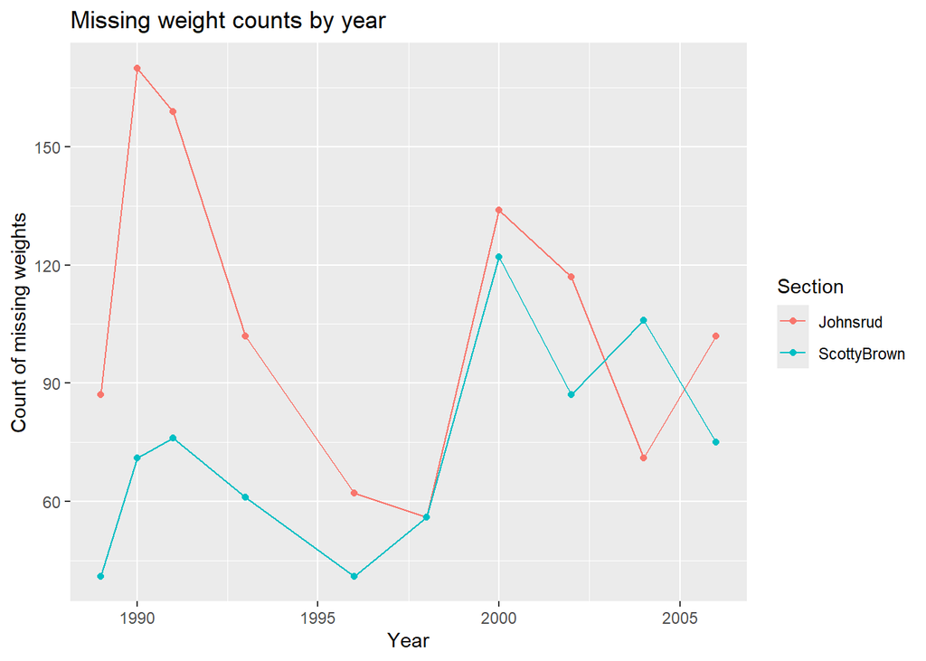

```r
missing_by_year <-
  fish |>
  filter(is.na(weight)) |>
  count(year, section, name = "n_missing")

ggplot(missing_by_year, aes(x = year, y = n_missing, color = section, group = section)) +
  geom_line() +
  geom_point() +
  labs(
    title = "Missing weight counts by year",
    x = "Year", y = "Count of missing weights", color = "Section"
  )
```

## Rescaling the Data

If I wanted to rescale every quantitative variable in my dataset so that they only have values between 0 and 1, I could use this code:

```r
fish <- fish |>
  mutate(length = (length - min(length, na.rm = TRUE)) /
           (max(length, na.rm = TRUE) - min(length, na.rm = TRUE)),
         weight = (weight - min(weight, na.rm = TRUE)) /
           (max(weight, na.rm = TRUE) - min(length, na.rm = TRUE)))
```

**4. Transform the repeated process above into a `rescale_01()` function. Your function should…**

- **… take a single vector as input.**
- **… return the rescaled vector.**

```r
rescale_01 <- function(x, na.rm = TRUE) {
  if (!is.numeric(x)) stop("`x` must be numeric.")
  if (length(x) <= 1) stop("`x` must have length > 1.")

  if (all(is.na(x))) return(x)
  r <- range(x, na.rm = na.rm)
  rng <- r[2] - r[1]
  if (rng == 0) return(ifelse(is.na(x), NA_real_, 0))
  (x - r[1]) / rng
}
```

**Efficiency**

Think about the efficiency of the function you wrote. Are you calling the **same** function multiple times? You might want to look into the `range()` function.

**5. Let’s incorporate some input validation into your function. Modify your previous code so that the function stops if …**

- **… the input vector is not numeric.**
- **… the length of the input vector is not greater than 1.**

**Modify Previous Code**

Do not create a new code chunk here – simply add these stops to your function above!

## Test Your Function

**6. Run the code below to test your function. Verify that the maximum of your rescaled vector is 1 and the minimum is 0!**

```r
x <- c(1:25, NA)

rescaled <- rescale_01(x)
min(rescaled, na.rm = TRUE)
```

```
[1] 0
```

```r
max(rescaled, na.rm = TRUE)
```

```
[1] 1
```

Next, let’s test the function on the `length` column of the `BlackfootFish` data.

**7. The code below makes a histogram of the original values of `length`. Add a plot of the rescaled values of `length`. Output your plots side-by-side, so the reader can confirm the only aspect that has changed is the scale.**

**Warning**

This will require you to call your `rescale_01()` function within a `mutate()` statement in order to create a `length_scaled` variable.

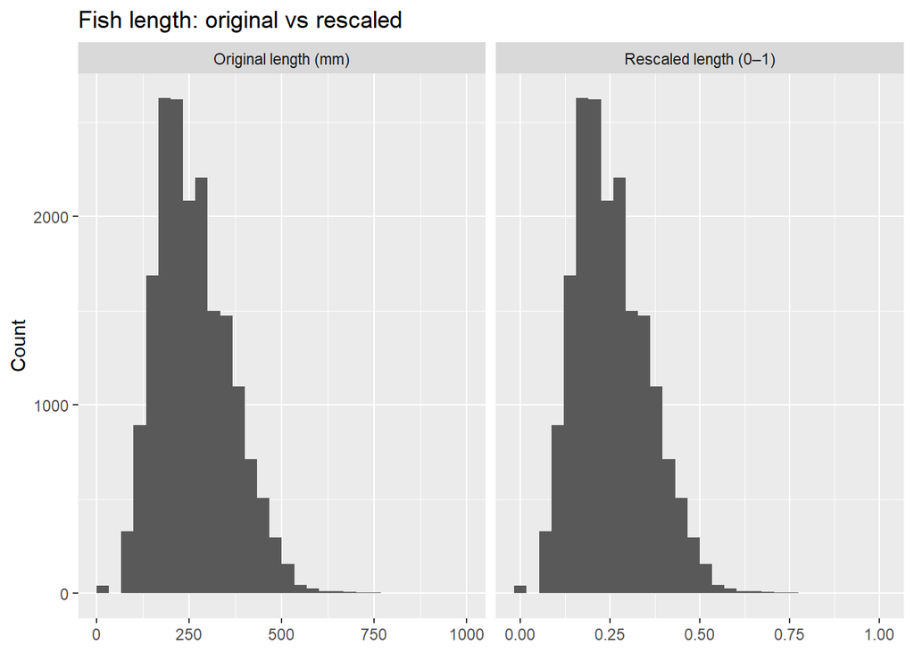

```r
# Code for Q7 plot.

fish |>
  mutate(length_scaled = rescale_01(length)) |>
  select(length, length_scaled) |>
  pivot_longer(everything(), names_to = "measure", values_to = "value") |>
  ggplot(aes(x = value)) +
  geom_histogram(bins = 30, na.rm = TRUE) +
  facet_wrap(
    ~ measure,
    scales = "free_x",
    labeller = as_labeller(c(
      length = "Original length (mm)",
      length_scaled = "Rescaled length (0–1)"
    ))
    #https://r-charts.com/ggplot2/facets/
    # I used this online source just for the many arguments of facet_wrap and to make sure I was using it right
  ) +
  labs(
    title = "Fish length: original vs rescaled",
    x = NULL, y = "Count"
  )
```

**Tip**

1. Set the y-axis limits for both plots to go from 0 to 4000 to allow for direct comparison across plots.
2. Pay attention to `binwidth`!
3. Use a Quarto code chunk option to put the plots side-by-side.